# E91 Performance Analyzer (via CHSH)

### Adapted for Qiskit 1.0

#### Vincenzo Orsini - P65000010

Si inizia con l'import delle librerie necessarie. N.B: A partire da Qiskit 0.46 la funzione Execute è deprecata. I job sono dunque da inizializzare con la funzione traspile

```python
import numpy as np
import random
import re #regular expression
import matplotlib.pyplot as plt
from qiskit.quantum_info import Statevector
from qiskit import QuantumCircuit, QuantumRegister, ClassicalRegister, transpile
from qiskit_aer import Aer
from qiskit.visualization import plot_histogram, plot_bloch_vector, plot_bloch_multivector
```

## Caso 1: assenza di EavesDropper

### Inizializzazione

```python
qr = QuantumRegister(2, name="qr")
cr = ClassicalRegister(4, name="cr")
```

In particolare si evidenziano i 2 qubit di riferimento (che saranno in stato di singoletto) e non 2, bensì 4 bit classici. La scelta è volta all'utilità futura, in cui, in presenza di Eve, saranno utilizzati tutti e 4. In presenza di soli Alice e Bob rimangono utilizzati solo i primi 2

Il singoletto, come ogni stato di Bell, prevede l'uso del Gate di Hadamrd su $q_0$ e poi del gate di controllo CNOT pilotato da $q_1$ su $q_2$. In più vanno anteposti due gate NOT ad inizio circuito.

$|\psi> \implies |00> \implies |11> \implies \frac{1}{\sqrt{2}}(|01>-|11>) \implies \frac{1}{\sqrt{2}}(|01>-|10>)$

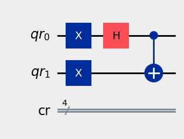

```python
singlet = QuantumCircuit(qr, cr, name='singlet')
singlet.x(qr[0])
singlet.x(qr[1])
singlet.h(qr[0])
singlet.cx(qr[0],qr[1])

singlet.draw(output='mpl', style={'backgroundcolor': '#EEEEEE'})
```

### Basi di Misura

- per la base computazionale (Z) basta l'operazione di misura;
- per la base di Hadamard, essendo l'omonima trasformazione Unitaria (Gate) autoaggiunto, basta apporre un gate H prima della misura;
- per la base W (V) si è proceduto apponendo un gate di Rotazione $R_y(-\frac{\pi}{4})$ $\left(R_y(\frac{\pi}{4})\right)$ seguito da un Pauli-Z

```python
## Alice's measurement circuits

# lungo la base X (Hadamard)
measureA1 = QuantumCircuit(qr, cr, name='measureA1')
measureA1.h(qr[0])
measureA1.measure(qr[0],cr[0])

# Lungo la base W (X+Z)/sqrt(2)
measureA2 = QuantumCircuit(qr, cr, name='measureA2')
measureA2.ry(-np.pi/4,0)
measureA2.z(0)
measureA2.measure(qr[0],cr[0])

# lungo la base Z (computazionale)
measureA3 = QuantumCircuit(qr, cr, name='measureA3')
measureA3.measure(qr[0],cr[0])
```

```
<qiskit.circuit.instructionset.InstructionSet at 0x161f32fe500>
```

```python
## Bob's measurement circuits

# Lungo la base W (X+Z)/sqrt(2)
measureB1 = QuantumCircuit(qr, cr, name='measureB1')
measureB1.ry(-np.pi/4,1)
measureB1.z(1)
measureB1.measure(qr[1],cr[1])

# lungo la base Z (computazionale)
measureB2 = QuantumCircuit(qr, cr, name='measureB2')
measureB2.measure(qr[1],cr[1])

# Lungo la base W (-X+Z)/sqrt(2)
measureB3 = QuantumCircuit(qr, cr, name='measureB3')
measureB3.ry(np.pi/4,1)
measureB3.z(1)
measureB3.measure(qr[1],cr[1])

## Lista delle basi di misura
aliceMeasurements = [measureA1, measureA2, measureA3]
bobMeasurements = [measureB1, measureB2, measureB3]
```

### Ragioni della trasformazione per le basi W e V

Si prenda in esame la base $W=\frac{X+Z}{\sqrt{2}}$ (speculare per V). Risulta $n_W=\left(\frac{1}{\sqrt{2}},0,\frac{1}{\sqrt{2}}\right)$.

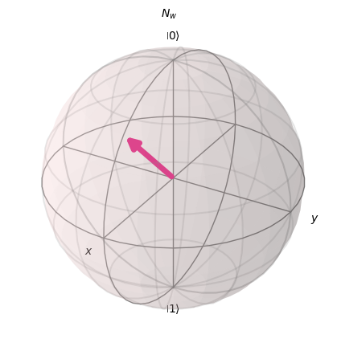

```python
plot_bloch_vector([1/np.sqrt(2),0,1/np.sqrt(2)], title="$N_w$", figsize=(5,4))
```

Bisogna dunque trovare una trasformazione tale da muoversi dallo stato in base computazionale di $45°$ lungo l'asse y, e successivamente invertirla. Ci si attende dunque $$U \begin{bmatrix} 1 \\ 0 \end{bmatrix} = \begin{bmatrix} \cos(\frac{\pi}{8}) \\ \sin(\frac{\pi}{8}) \end{bmatrix} \quad U \begin{bmatrix} 0 \\ 1 \end{bmatrix} = \begin{bmatrix} \sin(\frac{\pi}{8}) \\ -\cos(\frac{\pi}{8}) \end{bmatrix}$$

Il paper suggeriva di utilizzare $U=SHTH$ per effettuare una misura in base W, con

$$S=\begin{bmatrix} 1 & 0 \\ 0 & i\end{bmatrix} \quad T=\begin{bmatrix} 1 & 0 \\ 0 & e^{i\frac{\pi}{4}}\end{bmatrix}$$

dunque la trasformazione $$U^{\dagger}=HT^{\dagger}HS^{\dagger}$$ per passare dalla base computazionale alla base W

```
cos(pi/8):  0.9238795325112867 sin(pi/8):  0.3826834323650898
Psi= [(0.8535533905932735-0.3535533905932737j), (0.3535533905932737-0.1464466094067262j)]
|Psi|= 0.9238795325112865 0.3826834323650897
```

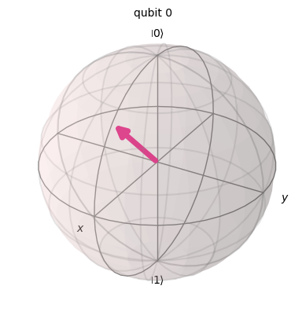

```python
Z_to_W = QuantumCircuit(1)
Z_to_W.h(0), Z_to_W.tdg(0), Z_to_W.h(0), Z_to_W.sdg(0)

print("cos(pi/8): ", np.cos(np.pi/8), "sin(pi/8): ", np.sin(np.pi/8))
state = Statevector(Z_to_W)
print("Psi=", list(state))
print("|Psi|=", abs(state[0]), abs(state[1]))
plot_bloch_multivector(state)
```

Quanto suggerito dal paper risulta dunque corretto, sebbene solo considerando il modulo delle componenti del vettore di stato. Pertanto si è preferito operare con semplici operatori di rotazione. Per il passaggio rispettivamente da base Z a W e viceversa dunque: $$ U=\sigma_Z R_y(\frac{\pi}{4}) \implies U^{\dagger}=R_y(-\frac{\pi}{4})\sigma_Z$$ con $$R_y(\theta)=\begin{bmatrix} \cos(\frac{\theta}{2}) & -\sin(\frac{\theta}{2}) \\ \sin(\frac{\theta}{2}) & \cos(\frac{\theta}{2})\end{bmatrix} \quad \sigma_Z=\begin{bmatrix} 1 & 0 \\ 0 & -1\end{bmatrix}$$ (il $\sigma_z$ occorre per lo stato $|1>$

```
cos(pi/8):  0.9238795325112867 sin(pi/8):  0.3826834323650898
Psi_0 = [(0.9238795325112867+0j), (0.3826834323650898+0j)] Psi_1 = [(0.38268343236508984+0j), (-0.9238795325112867+0j)]
```

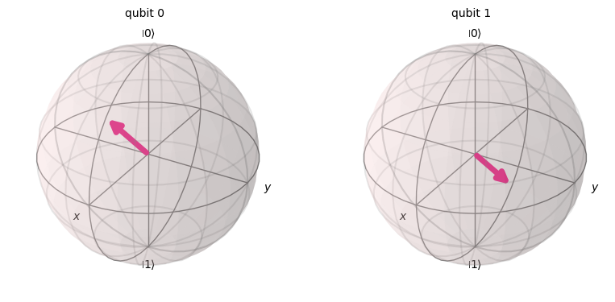

```python
print("cos(pi/8): ", np.cos(np.pi/8), "sin(pi/8): ", np.sin(np.pi/8))
Z_to_W = QuantumCircuit(2)
Z_to_W.z(0), Z_to_W.ry(np.pi/4, 0)
state_0 = list(Statevector(Z_to_W))
Z_to_W.x(1), Z_to_W.z(1), Z_to_W.ry(np.pi/4, 1)
state = list(Statevector(Z_to_W))
Z_to_W.reset(0)
state_1 = list(Statevector(Z_to_W))
print("Psi_0 =", state_0[0:2], "Psi_1 =", state_1[0::2])
plot_bloch_multivector(state)
```

#### Definite le componenti del circuito, si prepara la simulazione scegliendo un numero di coppie EPR da generere

```python
# Definiamo il numero di singoletti da generare
numberOfSinglets = 500
```

Per ciascun singoletto, viene estratta la base di misurazione scelta da Alice e da Bob

```python
aliceMeasurementChoices = [random.randint(1, 3) for i in range(numberOfSinglets)]
bobMeasurementChoices = [random.randint(1, 3) for i in range(numberOfSinglets)]
# per Alice: 1-X, 2-W, 3-Z; per Bob: 1-W, 2-Z, 3-V
```

È possibile infine costruire il circuito completo per ciasun singoletto

```python
circuits = [] # the list in which the created circuits will be stored

for i in range(numberOfSinglets):
    #aggiungiamo le misure al singoletto sulla base della scelta della base di misura
    circuitName = singlet.compose(aliceMeasurements[aliceMeasurementChoices[i]-1])
    circuitName = circuitName.compose(bobMeasurements[bobMeasurementChoices[i]-1])
    # aggiungiamo alla lista circuiti totale
    circuits.append(circuitName)
```

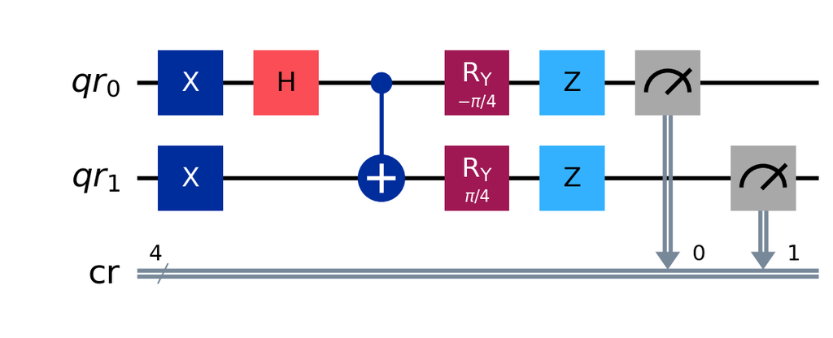

```python
#disegniamo uno dei circuiti totali ad esempio
circuits[0].draw('mpl', scale=2)
```

### È possibile ora creare l'istanza di simulazione ed avviarla

```python
# Iniziamo a simulare
backend=Aer.get_backend('qasm_simulator')
results=[]
for i in circuits:
    trans_circuit = transpile(i, backend=backend)
    result = backend.run(trans_circuit, shots = 1).result()
    results.append(result)
    # aggiungiamo i risultati ottenuti per ciascun singoletto ad una lista unica
```

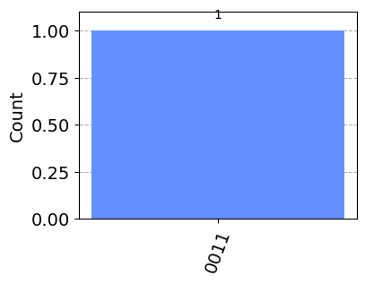

```python
plot_histogram(results[0].get_counts(), figsize=(4,3)) #ad esempio, per il primo singoletto
```

Vengono ora ricercati, nella lista dei risultati, i pattern indicanti gli esiti delle misure di Alice e Bob. La ricerca avviene solo sugli ultimi due bit computazionali, in quanto Eve è assente

```python
abPatterns = [
    re.compile('..00$'), # ricerca per output '..00' (Alice ha ottenuto -1 e Bob -1)
    re.compile('..01$'), # ricerca per output '..01' (Alice ha ottenuto 1 e Bob -1)
    re.compile('..10$'), # ricerca per output '..10' (Alice ha ottenuto -1 e Bob 1)
    re.compile('..11$')  # ricerca per output '..11' (Alice ha ottenuto 1 e Bob 1)
]
```

```python
aliceResults = []
bobResults = []

for i in range(numberOfSinglets):

    res = list(results[i].get_counts().keys())[0] # estrazione della chiave per ciascun dizionario (singoletto) come stringa
    # da qui partono i check con i pattern designati prima
    if abPatterns[0].search(res):
        aliceResults.append(-1) # Alice ha ottenuto -1
        bobResults.append(-1) # Bob ha ottenuto -1
    if abPatterns[1].search(res):
        aliceResults.append(1)
        bobResults.append(-1)
    if abPatterns[2].search(res):
        aliceResults.append(-1)
        bobResults.append(1)
    if abPatterns[3].search(res):
        aliceResults.append(1)
        bobResults.append(1)
```

Ricordando le configurazioni in cui Alice e Bob misurano nella stessa base Ricordando

$$ b_i = 1: \quad \vec{a}_1 = (1,0,0) \quad \qquad\qquad\qquad b_j^{'} = 1: \quad \vec{b}_1 = \left(\frac{1}{\sqrt{2}},0,\frac{1}{\sqrt{2}}\right) \quad $$$$ b_i = 2: \quad \vec{a}_2 = \left(\frac{1}{\sqrt{2}},0,\frac{1}{\sqrt{2}}\right) \quad \qquad\qquad\qquad b_j^{'} = 2: \quad \vec{b}_2 = (0,0,1) \quad $$$$ b_i = 3: \quad \vec{a}_3 = (0,0,1) \quad \qquad\qquad\qquad b_j^{'} = 3: \quad \vec{b}_3 = \left(-\frac{1}{\sqrt{2}},0,\frac{1}{\sqrt{2}}\right) \quad $$

si hanno corrispondenze per $A2B1$ e $A3B2$. Si scartano dunque tutti i circuiti in cui la base è differente. Per ciascuno dei rimanenti, vengono aggiunti gli output delle rispettive misure alle chiavi di Alice e Bob. Trattandosi della configurazione di singoletto, Bob avrà sempre il valore opposto rispetto ad Alice, pertanto, per effettuare il match, gli si cambia segno

```python
aliceKey = [] # Chiave di Alice
bobKey = [] # Chiave di Bob

# valutazione dei risultati corrispondenti
for i in range(numberOfSinglets):
    # check se la base di misurazione è la stessa (a_2/b_1 o a_3/b_2)
    if (aliceMeasurementChoices[i] == 2 and bobMeasurementChoices[i] == 1) or (aliceMeasurementChoices[i] == 3 and bobMeasurementChoices[i] == 2):
        aliceKey.append(aliceResults[i]) # In caso positivo aggiungi alla chiave il bit di Alice
        bobKey.append(- bobResults[i]) # In caso positivo aggiungi alla chiave il bit di Bob con il segno -

keyLength = len(aliceKey) # Lunghezza della chiave "certa"
```

In ultimo si effettua un check dei mismatch fra le due chiavi. Essendo costruite a partire da misure nella stessa base, e data l'assenza di Eve, ci si attende un numero pari a 0

```python
abKeyMismatches = 0 # check dei mismatch nella chiave certa (in questo caso dovrebbe essere 0)

for j in range(keyLength):
    if aliceKey[j] != bobKey[j]:
        abKeyMismatches += 1

print("Mismatches: ", abKeyMismatches)
```

```
Mismatches:  0
```